[figure not shown]

MRC Integrative Epidemiology Unit

Epigenetic Epidemiology Update

Matthew Suderman

MRC Integrative Epidemiology Unit

June 7, 2021

[figure not shown]

MRC Integrative Epidemiology Unit

EWAS of COVID-19

PMID

Phenotype

Tissue

Study population

Assocs

33867313

1

COVID

-19 severity

Blood

194 mild, 213 severe

44

34034806

2

COVID

-19 outcome

COVID

-19 severity

Blood

102 cases, 39

ctrls

100 cases

1505 DMRs (

DMRcate)

19 DMRs

1

Create ‘EPICOVID’ score for predicting severity but use 44 CpG sites which were replicated

in testing dataset.

2

Reference first study in Discussion but make no effort to compare findings.

[figure not shown]

MRC Integrative Epidemiology Unit

EWAS of risk

PMID

Disease

Tissue

Study population

Assocs

34008478*

Lung cancer risk

Blood

208 pre

-diagnostic cases, 222 ctrls

16

33980183

CVD risk

Blood

83 pre

-diagnostic cases, 83 matched ctrls

8

33964519

PTSD

Blood

74 PTSD, 75 traumatized

ctrls, 75 ctrls

?

*Controlled for smoking using a DNA methylation smoking so no typical smoking CpG sites

included in the 16.

[figure not shown]

MRC Integrative Epidemiology Unit

EWAS of exposure

PMID

Exposure

Tissue

Study population

Assocs

34044884

Sex

Placenta

343 placentas

162

33990564

Coffee and tea intake

Blood

15789 (15 cohorts)

11 (coffee)

33993705

Alcohol intake

Blood

57 MZ twins

1

Cpg site has never been linked to alcohol intake previously.

MRC Integrative Epidemiology Unit

Single-cell epigenetics of T1D

Chiou J, et al. Interpreting type 1 diabetes risk with genetics and single-cell epigenomics.

Nature. 2021 May 19.

1. GWAS of type 1 diabetes (n=520,850 samples)

2. Create ‘open chromatin’ profiles for individual blood and pancreas cells (snATAC-seq for

131,544 nulcei)

3. Use snATAC-seq profiles to cluster nuclei by cell-type

4. Test enrichment of T1D genetic variants in open chromatin by cell type

- T1D variants enriched in various T cells in blood but not in pancreas immune cells!

- however, restricting to cell-type-specific open chromatin identified enrichments in

pancreatic cell types like beta cells

5. Pursue story of CFTR locus which contains one T1D variant …

MRC Integrative Epidemiology Unit

Single-cell epigenetics of Atherosclerosis

Örd T, et al. Single-Cell Epigenomics and Functional Fine-Mapping of Atherosclerosis

GWAS Loci. Circ Res. 2021 May 24.

• 7,000 cells derived from human atherosclerotic lesions

• 5 lesional cell types identified

• Coronary Artery Disease associated genetic variants enriched in endothelial and smooth

muscle cell-specific open chromatin

• “We present several examples where the chromatin accessibility and gene expression could

be assigned to one cell type predicting the cell type of action for CAD loci.”

MRC Integrative Epidemiology Unit

Omics analysis of hypertension and the kidney

Eales JM, et al. Uncovering genetic mechanisms of hypertension through multi-omic

analysis of the kidney. Nat Genet. 2021 May;53(5):630-637.

Samples: n=430 kidneys

Data: blood pressure, genotype, gene expression, alternative splicing, DNA methylation

Previous GWAS of BP: 918 associations

Kidney drugs: 210 drugs that target 49

Methods:

• cis-eQTL, sQTL and mQTL analyses

• Two-Sample MR to evaluate

• effect of BP genetic variation on related outcomes (e.g. CHD)

• effect of renal genes/methylation on BP

MRC Integrative Epidemiology Unit

Omics analysis of hypertension and the kidney

Eales JM, et al. Uncovering genetic mechanisms of hypertension through multi-omic

analysis of the kidney. Nat Genet. 2021 May;53(5):630-637.

Results

• eQTL analysis links 232/918 BP SNPs (eSNPs) to genes (eGenes)

• sQTL analysis links 164/918 BP SNPs (sSNPs) to gene splicing (sGenes)

• mQTL analysis links 357/918 BP SNPs (mSNPs) to CpG methylation (mSites)

• Using eSNPs, sSNPs and mSNPs as MR instruments showed slightly stronger effects than

other BP SNPs for outcomes CHD and stroke but not different for other outcomes.

• Evidence for causal effects of 309 (e/sGenes/mSites) on BP

MRC Integrative Epidemiology Unit

Aging

Review of biomarkers

Li X, Ploner A, Wang Y, Zhan Y, Pedersen NL, Magnusson PK, Jylhävä J, Hägg S. Clinical biomarkers

and associations with healthspan and lifespan: Evidence from observational and genetic data.

EBioMedicine. 2021 Apr;66:103318.

Review of sex and aging

Hägg S, Jylhävä J. Sex differences in biological aging with a focus on human studies. Elife. 2021 May

13;10:e63425.

Skeletal muscle

Sillanpää E, et al. Blood and skeletal muscle ageing determined by epigenetic clocks and their

associations with physical activity and functioning. Clin Epigenetics. 2021 May 17;13(1):110.

“Based on our results, the investigated epigenetic clocks have rather low value in estimating muscle

ageing with respect to the physiological adaptations that typically occur due to ageing or PA.”

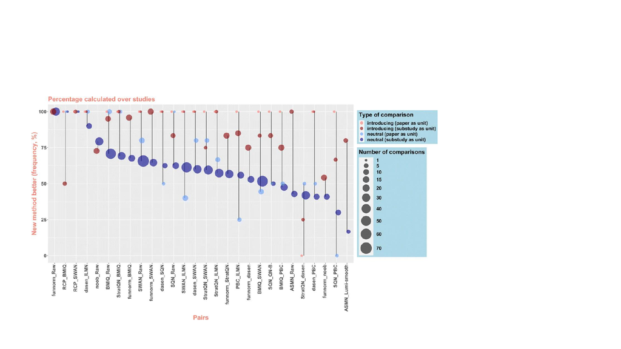

MRC Integrative Epidemiology Unit

Buchka S, et al. On the optimistic performance evaluation of newly introduced

bioinformatic methods. Genome Biol. 2021 May 11;22(1):152.

Methods

"For authors to feel

comfortable reporting

balanced results and

detailing the weaknesses of

their new methods, the

acceptance of nuanced

pictures and open

statements must increase."

"the general scientific

community and the journals

in particular can play a

positive role by

acknowledging that neutral

method-comparison studies

are valuable research

contributions"

MRC Integrative Epidemiology Unit

Methods

Banerjee S, et al. Tejaas: reverse regression increases power for detecting trans-eQTLs.

Genome Biol. 2021 May 6;22(1):142.

- Identify trans-eQTLs by testing association with all genes simultaneously using penalised

regression

- Identify 18,851 trans eQTLs in GTEx across 49 tissues (cf only 141 identified previously)

Talukder A, Barham C, Li X, Hu H. Interpretation of deep learning in genomics and

epigenomics. Brief Bioinform. 2021 May 20;22(3):bbaa177.

- Describe methods for interpreting deep neural network models

- Discuss how they have/can be applied in genomics and epigenomics

MRC Integrative Epidemiology Unit

Protein-wide association studies (PWAS)

Will be worth comparing associations of these outcomes/phenotypes with DNA methylation

and DNA methylation models of protein abundance.

Covid-19

Filbin MR, et al. Longitudinal proteomic analysis of severe COVID-19 reveals survival-

associated signatures, tissue-specific cell death, and cell-cell interactions. Cell Rep Med. 2021

May 18;2(5):100287.

Metabolic syndrome

Elhadad MA, et al. Metabolic syndrome and the plasma proteome: from association to

causation. Cardiovasc Diabetol. 2021 May 20;20(1):111.

Cardiorespiratory fitness

Robbins JM, et al. Human plasma proteomic profiles indicative of cardiorespiratory fitness. Nat

Metab. 2021 May 27.